[**Imtiaj.**](https://imtiajiqbalmahfuj.github.io/index.html#top)

# Automated Study Area Mapping and Spatio Harmonized Analytical (NDVI, LST, LULC) Visualization

### High-resolution cartography and spatial data integration using Python and Earth Engine

> *Streamlining reproducible, publication-ready study area maps for geospatial analysis 🗺️✨*

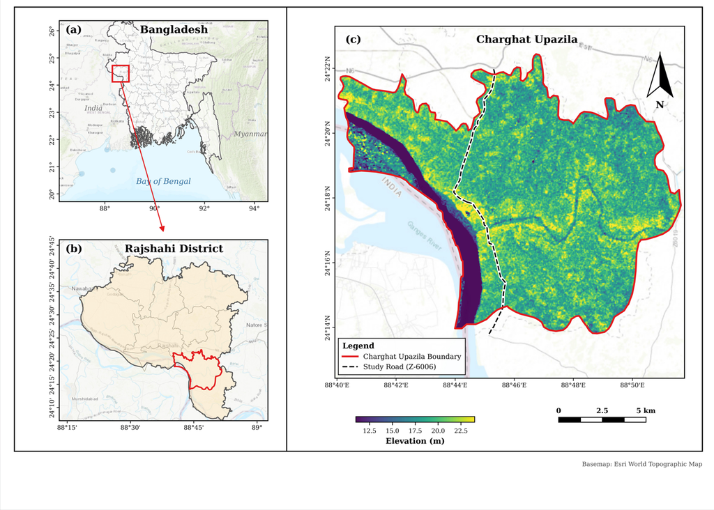

> **Author:** Imtiaj Iqbal Mahfuj

## 📝 Overview

This project explores **spatial patterns**, integrates **remote sensing datasets**, and applies **geospatial Python tools** to visualize and analyze the administrative and topographical landscapes of Bangladesh. It aims to uncover key insights that support data-driven decision-making for Urban Planning and Regional Development by automating the map-making process for complex study areas.

The primary objective of this workflow is to programmatically generate highly accurate, reproducible study area maps (incorporating boundaries, Digital Elevation Models, and infrastructure networks) directly from a Jupyter environment. By removing manual GIS processing steps, this pipeline accelerates spatial data analysis.

The beneficiaries of this project include academic researchers, urban planners, spatial data scientists, and policy-makers who require reliable, high-quality figures for reports and manuscripts.

In summary, the approach utilizes `geemap` and Google Earth Engine (GEE) to fetch administrative boundaries (Districts and Upazilas), auto-scaled DEMs, and OpenStreetMap (OSM) highway data. These layers are seamlessly rendered and exported as publication-ready visual assets.

## ⚙️ Methodology

[output not shown]

```python
# ==============================================================================
# MASTER 3-PANEL STUDY AREA MAP TEMPLATE  (v2)
# Layout: (a) Country + neighbours + Bay of Bengal / (b) District-or-Division (+basemap)
#         (c) Study area (AOI) with  ->  OSM layers  |  DEM  |  nothing
# ==============================================================================
import os
import re
import warnings
import textwrap
import numpy as np
import geopandas as gpd
import matplotlib.pyplot as plt
import matplotlib.patches as mpatches
import matplotlib.lines as mlines
import matplotlib.patheffects as pe
from matplotlib.colors import to_rgba
from matplotlib.legend_handler import HandlerTuple
from matplotlib.patches import Rectangle, Polygon, ConnectionPatch
from matplotlib.ticker import FuncFormatter, MultipleLocator
from shapely.geometry import mapping, box as sbox

warnings.filterwarnings("ignore")

try:
    import contextily as cx
except ImportError:
    cx = None

# ==============================================================================
# 2. USER CONFIGURATION
# ==============================================================================

# ---- 2.1 COUNTRY & ADMIN DATA ------------------------------------------------
COUNTRY = "Bangladesh"

DISTRICTS_SOURCE = "FAO/GAUL/2015/level2"
COUNTRY_SOURCE   = "FAO/GAUL/2015/level0"      # None -> dissolved from districts
UPAZILA_SOURCE   = "projects/geo-gee-imtiaj/assets/BGD_adm3_Upazilla"

F_COUNTRY, F_DIVISION, F_DISTRICT = "ADM0_NAME", "ADM1_NAME", "ADM2_NAME"

# ---- 2.2 STUDY AREA (AOI) ----------------------------------------------------
AOI_MODE = "NAME"       # "NAME" | "DISTRICTS" | "TABLE_ID"

AOI_NAME       = "Charghat"
AOI_SOURCE     = "projects/geo-gee-imtiaj/assets/BGD_adm3_Upazilla"
AOI_NAME_FIELD = "ADM3_NAME"

DISTRICTS = ["Rajshahi"]

AOI_DISPLAY_NAME = "Charghat Upazila"
AOI_SUFFIX       = None
DISTRICT_NAME    = "Rajshahi"

PANEL_B_EXTENT = "DISTRICT"        # "AUTO" | "DISTRICT" | "DIVISION"

TITLE_A_OVERRIDE = TITLE_B_OVERRIDE = TITLE_C_OVERRIDE = None
CAPTION_OVERRIDE = None

# ---- 2.3 PANEL (a): CONTEXT --------------------------------------------------
SHOW_CONTEXT_A    = True                                  # neighbours + Bay of Bengal
NEIGHBOUR_SOURCE  = "FAO/GAUL/2015/level0"                # GEE table or local file
CONTEXT_PAD_DEG   = 7                                     # how far around the country to load
SHOW_CONTEXT_LABELS = True                                # country names + "Bay of Bengal"
SEA_LABEL         = "Bay of Bengal"
SHOW_BASEMAP_A    = True
BASEMAP_A         = "topo"             # "topo" | "imagery" | "street" | "light"
BASEMAP_A_ALPHA   = 0.8

# ---- 2.4 PANEL (b): BASEMAP --------------------------------------------------
SHOW_BASEMAP_B    = True
BASEMAP_B         = "topo"             # "topo" | "imagery" | "street" | "light"
BASEMAP_B_ALPHA   = 0.8
DISTRICT_FILL_ALPHA = 0.55             # <1 lets the basemap show through the district

# ---- 2.5 PANEL (c): CONTENT --------------------------------------------------
SHOW_BASEMAP   = True
BASEMAP        = "topo"                # "topo" | "imagery" | "street" | "light"
BASEMAP_ALPHA  = 0.7
BASEMAP_ZOOM   = None

PANEL_C_LAYER  = "DEM"                 # "OSM" | "DEM" | "NONE"   <-- main switch

# DEM options (used when PANEL_C_LAYER == "DEM")
DEM_SCALE_M    = 30
DEM_CMAP, DEM_ALPHA = "viridis", 0.95

# OSM options (used when PANEL_C_LAYER == "OSM") - set any to False to hide it
OSM_LAYERS = dict(water=True, rivers=True, buildings=True, roads=True, rail=True)
OSM_RIVER_TYPES = ["river", "canal"]             # add "stream" for small streams
OSM_ROAD_EXCLUDE = ["footway", "path", "steps", "pedestrian", "cycleway",
                    "bridleway", "corridor", "proposed", "construction", "track"]
OSM_MAJOR_ROADS  = ["motorway", "trunk", "primary", "secondary",
                    "motorway_link", "trunk_link", "primary_link", "secondary_link"]
OSM_USE_CACHE    = True                # re-use downloaded layers on re-runs
OSM_STYLE = dict(
    water     = dict(color="#A9D3F5", label="Water body"),
    rivers    = dict(color="#3C8DD8", lw=1.0, label="River / canal"),
    buildings = dict(color="#8A8A8A", label="Building"),
    roads     = dict(color="#4D4D4D", lw_major=1.4, lw_minor=0.5, label="Road"),
    rail      = dict(color="black", lw=1.8, label="Railway"),
)
LEGEND_C_LOC = "lower left"
LEGEND_ROW_PAD = 0.03     # extra bottom padding (axes frac) per legend row in OSM mode

EXTRA_LAYERS = []

# ---- 2.6 COLORS --------------------------------------------------------------
COL_COUNTRY_FILL, COL_COUNTRY_LINE = "white", "#BDBDBD"
COL_COUNTRY_EDGE   = "#555555"
COL_DISTRICT_FILL  = "#FDE8C0"
COL_DISTRICT_EDGE  = "#9A9A9A"
COL_FOCAL_EDGE     = "#555555"
COL_UPAZILA_LINE   = "#B0A58F"
COL_AOI            = "#E41A1C"        # study-area outline: ONE solid colour
COL_LOCATOR        = "#E41A1C"
COL_FRAME          = "black"
COL_SEA, SEA_ALPHA = "#8EC3E8", 0.35  # Bay of Bengal / sea in panel (a)
COL_NEIGH_FILL, NEIGH_ALPHA = "#CFCFCF", 0.55
COL_NEIGH_EDGE     = "#9A9A9A"
COL_CTX_LABEL      = "#6B6B6B"
COL_SEA_LABEL      = "#2F6EA3"

AOI_LW_B, AOI_LW_C = 1.6, 2.0

# ---- 2.7 LAYOUT (figure fractions) ------------------------------------------
FIG_SIZE = (11.5, 8.2)
FIG_LEFT, FIG_RIGHT, FIG_BOTTOM, FIG_TOP = 0.02, 0.98, 0.115, 0.985
MID_X = 0.40
MID_Y = 0.55
GAP_X, GAP_Y = 0.008, 0.012

INNER_A = [0.15, 0.115, 0.80, 0.85]
INNER_B = [0.15, 0.115, 0.80, 0.85]
INNER_C = [0.105, 0.155, 0.865, 0.815]

# Extent padding (fraction of data extent): left, right, bottom, top
PAD_A = (0.40, 0.40, 0.38, 0.16)       # zoomed out so neighbours / Bay of Bengal show
PAD_B = (0.12, 0.12, 0.12, 0.20)
PAD_C = (0.10, 0.10, 0.16, 0.10)

# ---- 2.8 STYLE ---------------------------------------------------------------
FONT_FAMILY = "DejaVu Serif"
FONT_TITLE, FONT_MAIN, FONT_TICK, FONT_LEGEND = 12, 9, 7, 8
LW_OUTER, LW_MAP = 1.2, 1.0            # Reduced outer border width

# Coordinate label format: "deg" 88°  |  "dm" 88°42'  |  "dms"  |  "decimal"
FMT_A, FMT_B, FMT_C = "deg", "dm", "dm"
NBINS_A, NBINS_B, NBINS_C = (4, 5), (3, 4), (4, 5)
HEMI = dict(a=False, b=False, c=True)      # append E/N letters to labels
```

```python
# ---- 2.9 ELEMENT SWITCHES ----------------------------------------------------
SHOW_PANEL_BOXES   = False     # the inner (2nd-level) boxes around each panel
SHOW_LOCATOR       = True
SHOW_NORTH_ARROW   = dict(a=False, b=False, c=True)
SHOW_SCALEBAR      = dict(a=False, b=False, c=True)
SHOW_LEGEND        = dict(a=False, b=False, c=True)
SHOW_CAPTION       = True
SCALEBAR_C_POS     = (0.64, -0.125)
COLORBAR_C_POS     = [0.06, -0.125, 0.34, 0.016]

# ---- 2.10 OUTPUT -------------------------------------------------------------
OUTPUT_DIR      = "Final_Revised_Figures"
OUTPUT_BASENAME = "Fig1_Study_Area_Map"
SAVE_FORMATS    = ["png", "jpg"]
EXPORT_DPI      = 900
os.makedirs(OUTPUT_DIR, exist_ok=True)

# ==============================================================================
# 3. DATA HELPERS
# ==============================================================================
ee = geemap = None
NAME_FIELDS = ["NAME_3", "ADM3_NAME", "NAME_2", "ADM2_NAME", "NAME", "name", "Name",
               "UPAZILA", "Upazila", "upazila", "NAME_EN", "ADM_NAME"]

def init_ee():
    global ee, geemap
    if ee is not None: return
    import ee as _ee
    import geemap as _gm
    try: _ee.Initialize()
    except Exception:
        _ee.Authenticate()
        _ee.Initialize()
    ee, geemap = _ee, _gm

def read_vector(src, label, ee_filter=None, bbox=None):
    if os.path.exists(str(src)):
        g = gpd.read_file(src)
    else:
        init_ee()
        fc = ee.FeatureCollection(src)
        if ee_filter is not None: fc = ee_filter(fc)
        if bbox is not None: fc = fc.filterBounds(ee.Geometry.Rectangle([float(v) for v in bbox]))
        g = geemap.ee_to_gdf(fc)
    g = g.set_crs(4326) if g.crs is None else g.to_crs(4326)
    print(f"  {label}: {len(g)} features")
    return g

def read_neighbours(src, bbox):
    """Neighbouring countries clipped to bbox + simplified (keeps GEE payload small)."""
    if os.path.exists(str(src)):
        g = gpd.read_file(src)
        g = g.set_crs(4326) if g.crs is None else g.to_crs(4326)
        return gpd.clip(g, sbox(*bbox))
    init_ee()
    rect = ee.Geometry.Rectangle([float(v) for v in bbox])
    fc = ee.FeatureCollection(src).filterBounds(rect)
    fc = fc.map(lambda f: ee.Feature(f.geometry().intersection(rect, 1000).simplify(1000)).copyProperties(f))
    g = geemap.ee_to_gdf(fc)
    g = g.set_crs(4326) if g.crs is None else g.to_crs(4326)
    print(f"  Neighbours: {len(g)} features")
    return g

def union(g):
    geo = g.geometry
    return geo.union_all() if hasattr(geo, "union_all") else geo.unary_union

def join_names(names):
    names = [str(n) for n in names]
    return names[0] if len(names) == 1 else ", ".join(names[:-1]) + " & " + names[-1]

def find_field(gdf, preferred=None):
    if preferred and preferred in gdf.columns: return preferred
    for c in NAME_FIELDS:
        if c in gdf.columns: return c
    return None

def select_by_names(gdf, field, names, what):
    names = [names] if isinstance(names, str) else list(names)
    key = gdf[field].astype(str).str.strip().str.lower()
    want = [n.strip().lower() for n in names]
    return gdf[key.isin(want)]

def only_country(g):
    if F_COUNTRY in g.columns:
        g = g[g[F_COUNTRY].astype(str).str.lower() == COUNTRY.lower()]
    return g

print("\nLoading data ...")
_cf = (lambda fc: fc.filter(ee.Filter.eq(F_COUNTRY, COUNTRY)))
districts_all = only_country(read_vector(DISTRICTS_SOURCE, "Districts", _cf))
if COUNTRY_SOURCE:
    country_gdf = only_country(read_vector(COUNTRY_SOURCE, "Country", _cf))
else:
    country_gdf = districts_all.dissolve()
country_union = union(country_gdf)

# ---- Neighbouring countries for panel (a) ------------------------------------
neigh_gdf = None
if SHOW_CONTEXT_A:
    try:
        cb = country_gdf.total_bounds
        p = CONTEXT_PAD_DEG
        neigh_gdf = read_neighbours(NEIGHBOUR_SOURCE, (cb[0] - p, cb[1] - p, cb[2] + p, cb[3] + p))
        if F_COUNTRY in neigh_gdf.columns:
            neigh_gdf = neigh_gdf[neigh_gdf[F_COUNTRY].astype(str).str.lower() != COUNTRY.lower()]
    except Exception as e:
        print("Neighbour context skipped:", e)
        neigh_gdf = None

# ---- AOI ---------------------------------------------------------------------
mode = AOI_MODE.upper()
focal = None
if mode == "DISTRICTS":
    sel = select_by_names(districts_all, F_DISTRICT, DISTRICTS, "District")
    aoi_union = union(sel)
    aoi_name = join_names(DISTRICTS)
    auto_suffix = "Districts" if len(DISTRICTS) > 1 else "District"
    focal = sel
elif mode in ("TABLE_ID", "NAME"):
    raw = read_vector(AOI_SOURCE, "AOI table")
    fld = find_field(raw, AOI_NAME_FIELD)
    if mode == "NAME":
        raw = select_by_names(raw, fld, AOI_NAME, "AOI")
        aoi_name = join_names([AOI_NAME] if isinstance(AOI_NAME, str) else AOI_NAME)
    else:
        vals = [str(v) for v in raw[fld].dropna().unique()] if fld else []
        aoi_name = join_names(vals) if 0 < len(vals) <= 3 else "Study Area"
    aoi_union = union(raw)
    auto_suffix = ""
else:
    raise ValueError("AOI_MODE must be 'DISTRICTS', 'TABLE_ID' or 'NAME'.")

aoi_gdf = gpd.GeoDataFrame(geometry=[aoi_union], crs=4326)
suffix = auto_suffix if AOI_SUFFIX is None else AOI_SUFFIX
aoi_label = AOI_DISPLAY_NAME or f"{aoi_name} {suffix}".strip()

# ---- Panel (b) region --------------------------------------------------------
if focal is None:
    if DISTRICT_NAME:
        focal = select_by_names(districts_all, F_DISTRICT, DISTRICT_NAME, "District")
    else:
        cand = districts_all[districts_all.intersects(aoi_union)].copy()
        cand["_a"] = cand.geometry.intersection(aoi_union).area
        focal = cand.sort_values("_a", ascending=False).head(1)

b_mode = PANEL_B_EXTENT.upper()
if b_mode == "AUTO": b_mode = "DIVISION" if mode == "DISTRICTS" else "DISTRICT"
if b_mode == "DIVISION" and F_DIVISION in districts_all.columns:
    divs = list(focal[F_DIVISION].unique())
    context_gdf = districts_all[districts_all[F_DIVISION].isin(divs)]
    b_name = f"{join_names(divs)} Division"
else:
    context_gdf = focal
    fn = list(focal[F_DISTRICT])
    b_name = f"{join_names(fn)} District" + ("s" if len(fn) > 1 else "")
context_union = union(context_gdf)
b_bounds = context_union.bounds
```

```python
upazilas_gdf = None
if UPAZILA_SOURCE:
    try:
        up = read_vector(UPAZILA_SOURCE, "Upazilas", bbox=b_bounds)
        upazilas_gdf = up[up.representative_point().within(context_union)]
    except Exception as e: pass

# ---- Titles / legends / caption ----------------------------------------------
TITLE_A = TITLE_A_OVERRIDE or COUNTRY
TITLE_B = TITLE_B_OVERRIDE or b_name
TITLE_C = TITLE_C_OVERRIDE or aoi_label
LEGEND_C = f"{aoi_label} Boundary"
# CAPTION = CAPTION_OVERRIDE or (
#     f"Figure 1. Location of (a) {b_name} in {COUNTRY}; (b) {aoi_label} in {b_name}; "
#     f"and (c) base map of {aoi_label}.")

C_LAYER = PANEL_C_LAYER.upper()

# ---- Optional Auto-Scaling DEM -----------------------------------------------
dem_arr = vmin = vmax = None
if C_LAYER == "DEM":
    try:
        init_ee()
        print("Fetching DEM with payload auto-scaling...")
        geom = ee.Geometry(mapping(aoi_union))
        dem = ee.Image("USGS/SRTMGL1_003").rename("elevation")
        mask_band = ee.Image(1).clip(geom).unmask(0).rename("ROI_MASK")
        comb = dem.addBands(mask_band).unmask(-9999)

        current_scale = DEM_SCALE_M
        while True:
            try:
                arr = geemap.ee_to_numpy(comb, region=geom, scale=current_scale).astype(float)
                break
            except Exception as e:
                if "Total request size" in str(e) or "must be less than or equal to" in str(e):
                    current_scale += 30
                    print(f"Payload limit reached. Auto-adjusting DEM scale to {current_scale}m...")
                else:
                    raise e

        dem_arr = np.where(arr[:, :, 1] == 1, arr[:, :, 0], np.nan)
        dem_arr[dem_arr < -9000] = np.nan
        v = dem_arr[~np.isnan(dem_arr)]
        vmin, vmax = np.percentile(v, 2), np.percentile(v, 98)
    except Exception as e:
        print("DEM skipped:", e)
        dem_arr = None

# ---- Optional OSM layers (clipped to the AOI) ---------------------------------
osm_data = {}
if C_LAYER == "OSM":
    import osmnx as ox
    ox.settings.use_cache = True
    ox.settings.log_console = False
    slug = re.sub(r"[^A-Za-z0-9]+", "_", aoi_label).strip("_")
    OSM_CACHE_DIR = os.path.join(OUTPUT_DIR, "osm_cache")
    os.makedirs(OSM_CACHE_DIR, exist_ok=True)
    LINES, POLYS = ["LineString", "MultiLineString"], ["Polygon", "MultiPolygon"]

    def osm_features(poly, tags):
        fn = getattr(ox, "features_from_polygon", None) or ox.geometries_from_polygon
        return fn(poly, tags)

    def load_osm_layer(name, tags, kinds, post=None):
        cache = os.path.join(OSM_CACHE_DIR, f"{slug}_{name}.gpkg")
        if OSM_USE_CACHE and os.path.exists(cache):
            g = gpd.read_file(cache)
            print(f"  OSM {name}: {len(g)} features (cached)")
            return g
        try:
            g = osm_features(aoi_union, tags).reset_index(drop=True)
        except Exception as e:
            print(f"  OSM {name}: nothing found ({str(e)[:60]})")
            return None
        g = g[g.geom_type.isin(kinds)]
        keep = [c for c in ("highway", "waterway") if c in g.columns]
        g = g[keep + ["geometry"]].copy()
        for c in keep: g[c] = g[c].astype(str)
        if post is not None: g = post(g)
        if kinds is POLYS: g["geometry"] = g.geometry.buffer(0)
        g = gpd.clip(g, aoi_gdf)
        g = g[~g.geometry.is_empty & g.geometry.notna()]
        if len(g) == 0: return None
        g.to_file(cache, driver="GPKG")
        print(f"  OSM {name}: {len(g)} features")
        return g

    print("Fetching OSM layers ...")
    if OSM_LAYERS.get("water"):
        osm_data["water"] = load_osm_layer(
            "water", {"natural": "water", "waterway": "riverbank", "landuse": "reservoir"}, POLYS)
    if OSM_LAYERS.get("rivers"):
        osm_data["rivers"] = load_osm_layer(
            "rivers", {"waterway": OSM_RIVER_TYPES}, LINES,
            post=lambda g: g[g["waterway"].isin(OSM_RIVER_TYPES)] if "waterway" in g.columns else g)
    if OSM_LAYERS.get("buildings"):
        osm_data["buildings"] = load_osm_layer("buildings", {"building": True}, POLYS)
    if OSM_LAYERS.get("roads"):
        osm_data["roads"] = load_osm_layer(
            "roads", {"highway": True}, LINES,
            post=lambda g: g[~g["highway"].isin(OSM_ROAD_EXCLUDE)])
    if OSM_LAYERS.get("rail"):
        osm_data["rail"] = load_osm_layer("rail", {"railway": "rail"}, LINES)

# ==============================================================================
# 4. CARTOGRAPHY HELPERS
# ==============================================================================
SEXA = [10, 5, 2, 1, 0.5, 0.25, 1/6, 1/12, 1/30, 1/60, 1/120, 1/360, 1/720]
DECI = [10, 5, 2, 1, 0.5, 0.2, 0.1, 0.05, 0.02, 0.01, 0.005, 0.002, 0.001]
STEPS = {"deg": [20, 10, 5, 2, 1], "dm": SEXA[:9], "dms": SEXA, "decimal": DECI}

def make_locator(lim, n, fmt):
    span = abs(lim[1] - lim[0])
    steps = STEPS[fmt]
    for s in steps:
        if span / s >= n: return MultipleLocator(s)
    return MultipleLocator(steps[-1])

def make_formatter(fmt, axis, hemi=True):
    pos, neg = ("E", "W") if axis == "x" else ("N", "S")
    def f(v, _):
        h = (pos if v >= 0 else neg) if hemi else ""
        a = abs(v)
        if fmt == "dms":
            t = round(a * 3600)
            return f"{t // 3600}\u00b0{(t % 3600) // 60:02d}'{t % 60:02d}\"{h}"
        if fmt == "dm":
            d, m = divmod(round(a * 60), 60)
            return f"{d}\u00b0{h}" if m == 0 else f"{d}\u00b0{m:02d}'{h}"
        if fmt == "deg": return f"{a:g}\u00b0{h}"
        return f"{a:.2f}\u00b0{h}"
    return FuncFormatter(f)

def sub_rect(box, m): return [box[0] + m[0] * box[2], box[1] + m[1] * box[3], m[2] * box[2], m[3] * box[3]]
def rect(x0, y0, x1, y1): return [x0, y0, x1 - x0, y1 - y0]

def draw_box(fig, box, lw):
    fig.add_artist(Rectangle((box[0], box[1]), box[2], box[3], fill=False, edgecolor=COL_FRAME,
                             linewidth=lw, transform=fig.transFigure, clip_on=False))
```

```python
def gplot(obj, ax, **kw):
    obj.plot(ax=ax, aspect=None, **kw)

def make_map(fig, box, margin, bounds, title, pad, fmt, nbins, key):
    ax = fig.add_axes(sub_rect(box, margin))
    x0, y0, x1, y1 = bounds
    w, h = x1 - x0, y1 - y0
    ax.set_xlim(x0 - w * pad[0], x1 + w * pad[1])
    ax.set_ylim(y0 - h * pad[2], y1 + h * pad[3])
    aspect = 1 / np.cos(np.radians((y0 + y1) / 2))
    ax.set_aspect(aspect, adjustable="datalim")
    ax.apply_aspect()
    ax.xaxis.set_major_locator(make_locator(ax.get_xlim(), nbins[0], fmt))
    ax.yaxis.set_major_locator(make_locator(ax.get_ylim(), nbins[1], fmt))
    ax.xaxis.set_major_formatter(make_formatter(fmt, "x", HEMI[key]))
    ax.yaxis.set_major_formatter(make_formatter(fmt, "y", HEMI[key]))
    ax.tick_params(axis="both", direction="out", length=3, width=0.7, pad=2,
                   labelsize=FONT_TICK, top=False, right=False)
    ax.tick_params(axis="y", labelrotation=90)
    for lab in ax.get_yticklabels(): lab.set_va("center")
    for sp in ax.spines.values():
        sp.set_linewidth(LW_MAP)
        sp.set_edgecolor(COL_FRAME)
    tag = {"a": "(a)", "b": "(b)", "c": "(c)"}[key]
    bb = dict(facecolor="white", alpha=0.85, edgecolor="none", pad=1.5)
    ax.text(0.03, 0.975, tag, transform=ax.transAxes, ha="left", va="top", fontsize=FONT_TITLE,
            fontweight="bold", bbox=bb, zorder=100)
    ax.text(0.55, 0.975, textwrap.fill(title, 26 if key != "c" else 60), transform=ax.transAxes,
            ha="center", va="top", fontsize=FONT_TITLE, fontweight="bold", bbox=bb, zorder=100)
    ax._fixed = (aspect, ax.get_xlim(), ax.get_ylim())
    return ax

def fix_axes(ax):
    aspect, xl, yl = ax._fixed
    ax.set_aspect(aspect, adjustable="datalim")
    ax.set_xlim(xl)
    ax.set_ylim(yl)
    ax.apply_aspect()

def add_tiles(ax, name, alpha, zoom=None):
    if cx is None: return False
    # Reverted to WorldTopoMap by default to match the requested Esri style reference
    src = {"topo": cx.providers.Esri.WorldTopoMap,
           "imagery": cx.providers.Esri.WorldImagery,
           "street": cx.providers.OpenStreetMap.Mapnik,
           "light": cx.providers.CartoDB.Positron}[name]
    try:
        kw = dict(zoom=zoom) if zoom else {}
        cx.add_basemap(ax, crs="EPSG:4326", source=src, alpha=alpha, attribution=False, zorder=1, **kw)
        return True
    except Exception as e:
        print("Basemap skipped:", e)
        return False

def draw_aoi(ax, lw=2.0, z=20):
    """Study-area outline: a single solid colour line."""
    gplot(aoi_gdf.boundary, ax, color=COL_AOI, linewidth=lw, zorder=z)

def aoi_handle(lw=2.0):
    return mlines.Line2D([], [], color=COL_AOI, linewidth=lw)

def north_arrow(ax, x=0.93, y=0.80, h=0.12):
    bb = ax.get_window_extent()
    w = h * 0.30 * bb.height / bb.width
    top = (x, y + h)
    kw = dict(closed=True, edgecolor="black", linewidth=1.1, transform=ax.transAxes, zorder=90)
    ax.add_patch(Polygon([top, (x - w, y), (x, y + h * 0.25)], facecolor="white", **kw))
    ax.add_patch(Polygon([top, (x, y + h * 0.25), (x + w, y)], facecolor="black", **kw))
    ax.text(x, y - 0.012, "N", ha="center", va="top", fontsize=FONT_MAIN + 2, fontweight="bold",
            transform=ax.transAxes, zorder=90)

def scale_bar(ax, x, y, frac=0.30, nseg=4):
    x0, x1 = ax.get_xlim()
    y0, y1 = ax.get_ylim()
    kmdeg = 111.32 * np.cos(np.radians((y0 + y1) / 2))
    target = (x1 - x0) * kmdeg * frac
    L = max([v for v in [0.5, 1, 2, 5, 10, 20, 25, 50, 100, 200, 250, 500] if v <= target] or [0.5])
    w = (L / kmdeg) / (x1 - x0)
    hgt, sw = 0.014, w / nseg
    for i in range(nseg):
        ax.add_patch(Rectangle((x + i * sw, y), sw, hgt, transform=ax.transAxes,
                               facecolor="black" if i % 2 == 0 else "white", edgecolor="black",
                               linewidth=0.9, clip_on=False, zorder=100))
    kw = dict(transform=ax.transAxes, ha="center", va="bottom", fontsize=FONT_MAIN - 1,
              fontweight="bold", clip_on=False, zorder=100)
    ax.text(x, y + hgt + 0.008, "0", **kw)
    ax.text(x + w / 2, y + hgt + 0.008, f"{L / 2:g}", **kw)
    ax.text(x + w, y + hgt + 0.008, f"{L:g} km", **kw)

def add_legend(ax, handles, labels, loc="lower left"):
    lg = ax.legend(handles, labels, loc=loc, fontsize=FONT_LEGEND, title="Legend",
                   title_fontsize=FONT_LEGEND + 1, frameon=True, framealpha=0.95, fancybox=False,
                   edgecolor="black", borderpad=0.6, handlelength=2.2, labelspacing=0.5,
                   alignment="left", handler_map={tuple: HandlerTuple(ndivide=None)})
    lg.get_title().set_fontweight("bold")
    lg.get_frame().set_linewidth(0.8)
    lg.set_zorder(150)
    return lg

def has(key):
    g = osm_data.get(key)
    return g is not None and len(g) > 0

def draw_osm(ax):
    """Draw enabled OSM layers (already clipped to AOI); return legend handles/labels."""
    S = OSM_STYLE
    hs, ls = [], []
    if has("water"):
        gplot(osm_data["water"], ax, facecolor=S["water"]["color"], edgecolor="none", zorder=3)
        hs.append(mpatches.Patch(facecolor=S["water"]["color"], edgecolor="none")); ls.append(S["water"]["label"])
    if has("rivers"):
        gplot(osm_data["rivers"], ax, color=S["rivers"]["color"], linewidth=S["rivers"]["lw"], zorder=4)
        hs.append(mlines.Line2D([], [], color=S["rivers"]["color"], linewidth=S["rivers"]["lw"] + 0.6)); ls.append(S["rivers"]["label"])
    if has("buildings"):
        gplot(osm_data["buildings"], ax, facecolor=S["buildings"]["color"], edgecolor="none", zorder=5)
        hs.append(mpatches.Patch(facecolor=S["buildings"]["color"], edgecolor="none")); ls.append(S["buildings"]["label"])
    if has("roads"):
        r = osm_data["roads"]
        major = r["highway"].isin(OSM_MAJOR_ROADS) if "highway" in r.columns else np.zeros(len(r), bool)
        if (~major).any(): gplot(r[~major], ax, color=S["roads"]["color"], linewidth=S["roads"]["lw_minor"], zorder=6)
        if major.any():    gplot(r[major],  ax, color=S["roads"]["color"], linewidth=S["roads"]["lw_major"], zorder=7)
        hs.append(mlines.Line2D([], [], color=S["roads"]["color"], linewidth=1.0)); ls.append(S["roads"]["label"])
    if has("rail"):
        lw = S["rail"]["lw"]
        gplot(osm_data["rail"], ax, color=S["rail"]["color"], linewidth=lw, zorder=8)
        gplot(osm_data["rail"], ax, color="white", linewidth=lw * 0.45, linestyle=(0, (4, 4)), zorder=9)
        hs.append((mlines.Line2D([], [], color=S["rail"]["color"], linewidth=lw),
                   mlines.Line2D([], [], color="white", linewidth=lw * 0.45, linestyle=(0, (2, 2)))))
        ls.append(S["rail"]["label"])
    return hs, ls
```

```python
# Pre-compute legend rows for panel (c) so the legend gets room inside the map
osm_rows = sum(1 for k in ("water", "rivers", "buildings", "roads", "rail") if has(k)) if C_LAYER == "OSM" else 0
if C_LAYER == "OSM" and osm_rows:
    PAD_C = (PAD_C[0], PAD_C[1], PAD_C[2] + LEGEND_ROW_PAD * osm_rows, PAD_C[3])


# ---- Fetch Study Road for Map (c) --------------------------------------------
print("Fetching Z-6006 highway from OpenStreetMap...")
import osmnx as ox
try:
    if hasattr(aoi_gdf.geometry, 'union_all'):
        aoi_poly = aoi_gdf.geometry.union_all()
    else:
        aoi_poly = aoi_gdf.geometry.unary_union

    osm_roads = ox.features_from_polygon(aoi_poly, tags={"highway": True})

    if "ref" in osm_roads.columns and osm_roads["ref"].str.contains("Z6006", na=False).any():
        study_road = osm_roads[osm_roads["ref"].str.contains("Z6006", na=False)]
    else:
        study_road = osm_roads[osm_roads["highway"].isin(["secondary", "primary"])]

    study_road = study_road.to_crs(epsg=4326)
except Exception as e:
    print(f"OSM fetch failed: {e}")
    study_road = None


# ==============================================================================
# 5. FIGURE
# ==============================================================================
print("\nRendering ...")
plt.rcParams.update({"font.family": FONT_FAMILY, "figure.dpi": 120, "savefig.dpi": EXPORT_DPI})
fig = plt.figure(figsize=FIG_SIZE, facecolor="white")

OUTER = rect(FIG_LEFT, FIG_BOTTOM, FIG_RIGHT, FIG_TOP)
PANEL_A = rect(FIG_LEFT + GAP_X, MID_Y + GAP_Y / 2, MID_X - GAP_X, FIG_TOP - GAP_Y)
PANEL_B = rect(FIG_LEFT + GAP_X, FIG_BOTTOM + GAP_Y, MID_X - GAP_X, MID_Y - GAP_Y / 2)
PANEL_C = rect(MID_X + GAP_X, FIG_BOTTOM + GAP_Y, FIG_RIGHT - GAP_X, FIG_TOP - GAP_Y)

# Initialize used_basemaps early so Panel A can append to it
used_basemaps = []

# the two main boxes: left column + right column
draw_box(fig, OUTER, LW_OUTER)
fig.add_artist(mlines.Line2D([MID_X, MID_X], [FIG_BOTTOM, FIG_TOP], transform=fig.transFigure,
                             color=COL_FRAME, linewidth=LW_OUTER))
if SHOW_PANEL_BOXES:
    for p in (PANEL_A, PANEL_B, PANEL_C): draw_box(fig, p, 1.2)

# ---------------- (a) COUNTRY + CONTEXT ----------------
ax_a = make_map(fig, PANEL_A, INNER_A, country_gdf.total_bounds, TITLE_A, PAD_A, FMT_A, NBINS_A, "a")

has_basemap_a = False
if SHOW_BASEMAP_A and cx is not None:
    if add_tiles(ax_a, BASEMAP_A, BASEMAP_A_ALPHA):
        used_basemaps.append(BASEMAP_A)
        has_basemap_a = True

if neigh_gdf is not None and len(neigh_gdf):
    if not has_basemap_a:
        ax_a.set_facecolor(to_rgba(COL_SEA, SEA_ALPHA))
    # If basemap is active, make neighbour fill more transparent to let the map show through
    n_alpha = 0.15 if has_basemap_a else NEIGH_ALPHA
    gplot(neigh_gdf, ax_a, facecolor=to_rgba(COL_NEIGH_FILL, n_alpha),
          edgecolor=COL_NEIGH_EDGE, linewidth=0.4, zorder=0.5)

# If basemap is active, make country fill semi-transparent
c_alpha = 0.45 if has_basemap_a else 1.0
gplot(districts_all, ax_a, facecolor=to_rgba(COL_COUNTRY_FILL, c_alpha),
      edgecolor=COL_COUNTRY_LINE, linewidth=0.35, zorder=1)

gplot(country_gdf.boundary, ax_a, color=COL_COUNTRY_EDGE, linewidth=0.8, zorder=2)
bx0, by0, bx1, by1 = b_bounds
if SHOW_LOCATOR:
    ax_a.add_patch(Rectangle((bx0, by0), bx1 - bx0, by1 - by0, fill=False, edgecolor=COL_LOCATOR,
                             linewidth=1.8, zorder=20))
else:
    gplot(context_gdf, ax_a, facecolor=COL_LOCATOR, edgecolor="black", linewidth=0.5, zorder=20)
if SHOW_LEGEND["a"]:
    add_legend(ax_a, [mlines.Line2D([], [], color=COL_LOCATOR, linewidth=1.8)], [b_name])
fix_axes(ax_a)

if SHOW_CONTEXT_LABELS and neigh_gdf is not None and len(neigh_gdf):
    xl, yl = ax_a.get_xlim(), ax_a.get_ylim()
    view = sbox(xl[0], yl[0], xl[1], yl[1])
    for _, r in neigh_gdf.iterrows():
        try:
            part = r.geometry.intersection(view)
            if part.is_empty or part.area < 0.02 * view.area: continue
            pt = part.representative_point()
            nm = str(r.get(F_COUNTRY, ""))
            if nm:
                ax_a.text(pt.x, pt.y, nm, ha="center", va="center", fontsize=FONT_TICK + 1,
                          style="italic", color=COL_CTX_LABEL, zorder=3)
        except Exception:
            pass
    cxm = (country_gdf.total_bounds[0] + country_gdf.total_bounds[2]) / 2
    ax_a.text(cxm, yl[0] + 0.11 * (yl[1] - yl[0]), SEA_LABEL, ha="center", va="center",
              fontsize=FONT_TICK + 2, style="italic", color=COL_SEA_LABEL, zorder=3)

if SHOW_NORTH_ARROW["a"]: north_arrow(ax_a)
if SHOW_SCALEBAR["a"]:    scale_bar(ax_a, 0.50, 0.05)

# ---------------- (b) DISTRICT / DIVISION (+ basemap) ----------------
ax_b = make_map(fig, PANEL_B, INNER_B, b_bounds, TITLE_B, PAD_B, FMT_B, NBINS_B, "b")
fill_b = to_rgba(COL_DISTRICT_FILL, 1.0)
if SHOW_BASEMAP_B and add_tiles(ax_b, BASEMAP_B, BASEMAP_B_ALPHA):
    used_basemaps.append(BASEMAP_B)
    fill_b = to_rgba(COL_DISTRICT_FILL, DISTRICT_FILL_ALPHA)
gplot(context_gdf, ax_b, facecolor=fill_b, edgecolor=COL_DISTRICT_EDGE, linewidth=0.6, zorder=2)
if upazilas_gdf is not None:
    gplot(upazilas_gdf.boundary, ax_b, color=COL_UPAZILA_LINE, linewidth=0.5, zorder=3)
gplot(focal.boundary, ax_b, color=COL_FOCAL_EDGE, linewidth=1.1, zorder=4)
draw_aoi(ax_b, lw=AOI_LW_B)
if SHOW_LEGEND["b"]: add_legend(ax_b, [aoi_handle(AOI_LW_B)], [aoi_label])
fix_axes(ax_b)
if SHOW_NORTH_ARROW["b"]: north_arrow(ax_b)
if SHOW_SCALEBAR["b"]:    scale_bar(ax_b, 0.50, 0.05)

# ---------------- (c) STUDY AREA ----------------
ax_c = make_map(fig, PANEL_C, INNER_C, aoi_union.bounds, TITLE_C, PAD_C, FMT_C, NBINS_C, "c")

if SHOW_BASEMAP and cx is not None:
    if add_tiles(ax_c, BASEMAP, BASEMAP_ALPHA, BASEMAP_ZOOM): used_basemaps.append(BASEMAP)
else:
    gplot(aoi_gdf, ax_c, facecolor="#F4F4F4", edgecolor="none", zorder=1)

im = None
legend_h, legend_l = [], []
if C_LAYER == "DEM" and dem_arr is not None:
    ab = aoi_union.bounds
    im = ax_c.imshow(dem_arr, cmap=DEM_CMAP, vmin=vmin, vmax=vmax, alpha=DEM_ALPHA, zorder=2,
                     extent=[ab[0], ab[2], ab[1], ab[3]], aspect=ax_c._fixed[0])
elif C_LAYER == "OSM":
    legend_h, legend_l = draw_osm(ax_c)
```

```
Loading data ...
  Districts: 64 features
  Country: 1 features
  Neighbours: 8 features
  AOI table: 463 features
  Upazilas: 23 features
Fetching DEM with payload auto-scaling...
Fetching Z-6006 highway from OpenStreetMap...

Rendering ...
```

```
Saved: Final_Revised_Figures\Fig1_Study_Area_Map.png
```

```
Saved: Final_Revised_Figures\Fig1_Study_Area_Map.jpg
```

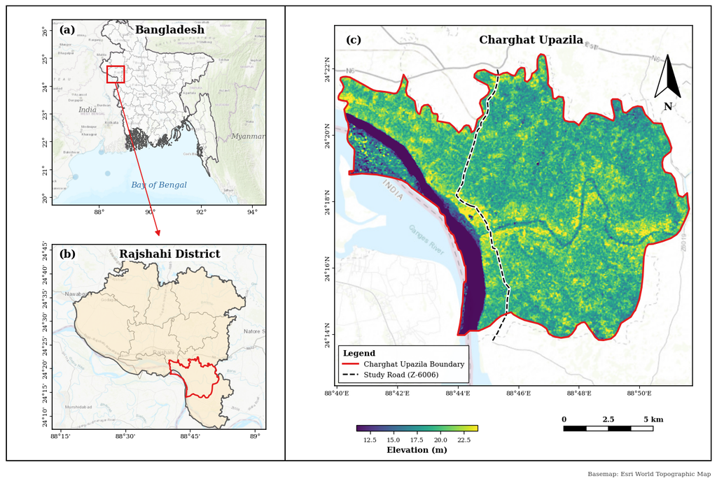

```python
draw_aoi(ax_c, lw=AOI_LW_C)

# Draw the Study Road and add it to the legend lists
if study_road is not None and not study_road.empty:
    study_road.plot(ax=ax_c, color='white', linewidth=3.5, zorder=12)
    study_road.plot(ax=ax_c, color='black', linewidth=1.5, linestyle='--', zorder=13)

    legend_h.append(mlines.Line2D([], [], color='black', linewidth=1.5, linestyle='--'))
    legend_l.append('Study Road (Z-6006)')

fix_axes(ax_c)

if SHOW_NORTH_ARROW["c"]: north_arrow(ax_c)
if SHOW_SCALEBAR["c"]:    scale_bar(ax_c, *SCALEBAR_C_POS)
if SHOW_LEGEND["c"]:
    add_legend(ax_c, [aoi_handle(AOI_LW_C)] + legend_h, [LEGEND_C] + legend_l, loc=LEGEND_C_LOC)
if im is not None:
    cax = ax_c.inset_axes(COLORBAR_C_POS)
    cb = fig.colorbar(im, cax=cax, orientation="horizontal")
    cb.set_label("Elevation (m)", fontsize=FONT_MAIN, fontweight="bold")
    cb.ax.tick_params(labelsize=FONT_TICK)

# ---------------- Locator arrow (a) -> (b) ----------------
if SHOW_LOCATOR:
    pb = ax_b.get_position()
    fig.add_artist(ConnectionPatch(
        xyA=((bx0 + bx1) / 2, by0), coordsA=ax_a.transData,
        xyB=((pb.x0 + pb.x1) / 2, PANEL_B[1] + PANEL_B[3]), coordsB="figure fraction",
        arrowstyle="-|>", mutation_scale=13, color=COL_LOCATOR, linewidth=1.1, zorder=200))

# ---------------- Caption + credits ----------------
# if SHOW_CAPTION:
#     fig.text(FIG_LEFT + 0.01, FIG_BOTTOM - 0.02, textwrap.fill(CAPTION, 95), ha="left", va="top",
#              fontsize=FONT_MAIN + 1)
# CREDITS = {"topo": "Esri World Topographic Map", "imagery": "Esri World Imagery",
#            "street": "\u00a9 OpenStreetMap", "light": "\u00a9 CARTO, \u00a9 OpenStreetMap"}
credit_txt = " | ".join(dict.fromkeys(CREDITS[k] for k in used_basemaps))
# if C_LAYER == "OSM": credit_txt = (credit_txt + " | " if credit_txt else "") + "Features: \u00a9 OpenStreetMap contributors"
if credit_txt:
    fig.text(FIG_RIGHT, FIG_BOTTOM - 0.02, f"Basemap: {credit_txt}", ha="right", va="top",
             fontsize=FONT_TICK, color="#444444")

# ==============================================================================
# 6. EXPORT
# ==============================================================================
for ext in SAVE_FORMATS:
    path = os.path.join(OUTPUT_DIR, f"{OUTPUT_BASENAME}.{ext}")
    fig.savefig(path, facecolor="white", dpi=EXPORT_DPI)
    print("Saved:", path)
plt.show()
```

```python
# ==============================================================================
# FULL ANALYSIS: 30m NATIVE HARMONIZATION, 2x2 GRIDS, AND REAL STATISTICS
# Addresses Reviewer 1 (Land-use) and Reviewer 2 (Native 30m GEE LST, 2x2 Layout)
# ==============================================================================
import os
import ee
import geemap
import numpy as np
import pandas as pd
import geopandas as gpd
import matplotlib.pyplot as plt
import matplotlib.patches as mpatches
from matplotlib.ticker import MaxNLocator, FuncFormatter
from mpl_toolkits.axes_grid1.inset_locator import inset_axes
import scipy.stats as stats
import warnings

warnings.filterwarnings("ignore")

# 1. Initialize Earth Engine
try:
    ee.Initialize()
except Exception:
    ee.Authenticate()
    ee.Initialize()

OUTPUT_DIR = "Final_Revised_Figures"
os.makedirs(OUTPUT_DIR, exist_ok=True)

plt.rcParams.update({
    'font.family': 'sans-serif', 'font.sans-serif': ['DejaVu Serif'],
    'font.size': 11, 'axes.titlesize': 12, 'axes.labelsize': 10,
    'figure.dpi': 500, 'savefig.dpi': 500, 'savefig.bbox': 'tight', 'savefig.format': 'jpg'
})

# 2. Define AOI and Spatial Bounding
AOI_ASSET_ID = 'projects/geo-gee-imtiaj/assets/Charghat_upazila_Rajshahi'
aoi_ee = ee.FeatureCollection(AOI_ASSET_ID)
aoi_gdf = geemap.ee_to_gdf(aoi_ee)
if aoi_gdf.crs is None:
    aoi_gdf = aoi_gdf.set_crs(epsg=4326)

bnds = aoi_gdf.total_bounds
imshow_extent = [bnds[0], bnds[2], bnds[1], bnds[3]]

# ==============================================================================
# 3. CARTOGRAPHY ENGINE FOR 2x2 GRIDS
# ==============================================================================
# def add_exact_north_arrow(ax, loc='upper right', size=0.15):
#     """Draws a fixed-ratio split-triangle North Arrow that will never stretch."""
#     ax_inset = inset_axes(ax, width=f"{size*100}%", height=f"{size*100}%", loc=loc, borderpad=1.0, axes_kwargs={'aspect': 'equal'})
#     ax_inset.axis('off')
#     ax_inset.set_xlim(0, 1)
#     ax_inset.set_ylim(0, 1)
#     x, y, w, h = 0.5, 0.85, 0.30, 0.8
#     # Left Half (White), Right Half (Black)
#     left_poly = plt.Polygon([[x, y], [x-w, y-h], [x, y-h*0.25]], facecolor='white', edgecolor='black', lw=1.2)
#     right_poly = plt.Polygon([[x, y], [x, y-h*0.25], [x+w, y-h]], facecolor='black', edgecolor='black', lw=1.2)
#     ax_inset.add_patch(left_poly)
#     ax_inset.add_patch(right_poly)
#     ax_inset.text(x, y-h-0.15, 'N', ha='center', va='top', fontsize=10, fontweight='bold')

def add_exact_north_arrow(ax, x=0.93, y=0.80, h=0.12):
    bb = ax.get_window_extent()
    # Reduced width from 0.30 to 0.15 to make the arrow sleeker/sharper
    w = h * 0.15 * bb.height / bb.width
    top = (x, y + h)
    kw = dict(closed=True, edgecolor="black", linewidth=1.1, transform=ax.transAxes, zorder=90)

    # Lowered the inner cutout from 0.25 to 0.15 for a deeper tail
    ax.add_patch(plt.Polygon([top, (x - w, y), (x, y + h * 0.15)], facecolor="white", **kw))
    ax.add_patch(plt.Polygon([top, (x, y + h * 0.15), (x + w, y)], facecolor="black", **kw))

    # Increased the text size for "N" (e.g., set to 14 or FONT_MAIN + 6)
    ax.text(x, y - 0.025, "N", ha="center", va="top", fontsize=14, fontweight="bold",
            transform=ax.transAxes, zorder=90)

# Changed y_pos from 0.03 to 0.06 to lift it higher off the bottom edge
def draw_exact_zebra_scalebar(ax_map, x_pos=0.03, y_pos=0.06):
    center_lat = (bnds[1] + bnds[3]) / 2
    m_per_deg = 111320 * np.cos(np.radians(center_lat))
    deg_width = (5 * 1000) / m_per_deg # Fixed 5km scale
    xmin, xmax = ax_map.get_xlim()
    w_ax = deg_width / (xmax - xmin)
    h_ax = 0.015
    for i in range(4):
        c = 'black' if i % 2 == 0 else 'white'
        ax_map.add_patch(mpatches.Rectangle((x_pos + i*(w_ax/4), y_pos), w_ax/4, h_ax, facecolor=c, edgecolor='black', lw=1.2, transform=ax_map.transAxes, zorder=100))

    # Increased fontsize from 10 to 12
    opts = {'fontsize': 12, 'fontweight': 'bold', 'transform': ax_map.transAxes, 'ha': 'center', 'va': 'top'}
    ax_map.text(x_pos, y_pos - 0.015, '0', **opts)
    ax_map.text(x_pos + w_ax/2, y_pos - 0.015, '2.5', **opts)
    ax_map.text(x_pos + w_ax, y_pos - 0.015, '5 km', **opts)

def apply_panel_style(ax, title, is_inner_y=False, is_inner_x=False):
    ax.set_title(title, pad=8, fontweight='bold', fontsize=12)
    ax.tick_params(top=True, bottom=True, left=True, right=True, direction='in',
                   labeltop=False, labelbottom=not is_inner_x, labelleft=not is_inner_y, labelright=False, pad=4, labelsize=9)
    ax.xaxis.set_major_locator(MaxNLocator(nbins=3, prune='both'))
    ax.yaxis.set_major_locator(MaxNLocator(nbins=4, prune='both'))
    ax.tick_params(axis='y', labelrotation=90)
    ax.xaxis.set_major_formatter(FuncFormatter(lambda x, _: f"{x:.2f}° E"))
    ax.yaxis.set_major_formatter(FuncFormatter(lambda y, _: f"{y:.2f}° N"))

    pad_x, pad_y = (bnds[2] - bnds[0]) * 0.02, (bnds[3] - bnds[1]) * 0.02
    ax.set_xlim(bnds[0] - pad_x, bnds[2] + pad_x); ax.set_ylim(bnds[1] - pad_y, bnds[3] + pad_y)

    for spine in ax.spines.values():
        spine.set_edgecolor('black'); spine.set_linewidth(1.2); spine.set_zorder(10)

    add_exact_north_arrow(ax)
    draw_exact_zebra_scalebar(ax)
```

```
Extracting actual 30m native Earth Engine data (2016, 2020, 2024)...
Extraction complete.
Fetching Z-6006 highway from OpenStreetMap...
Exact 'Z-6006' ref missing in OSM; fetching primary regional roads instead.
Rendering 2x2 Map for NDVI...
```

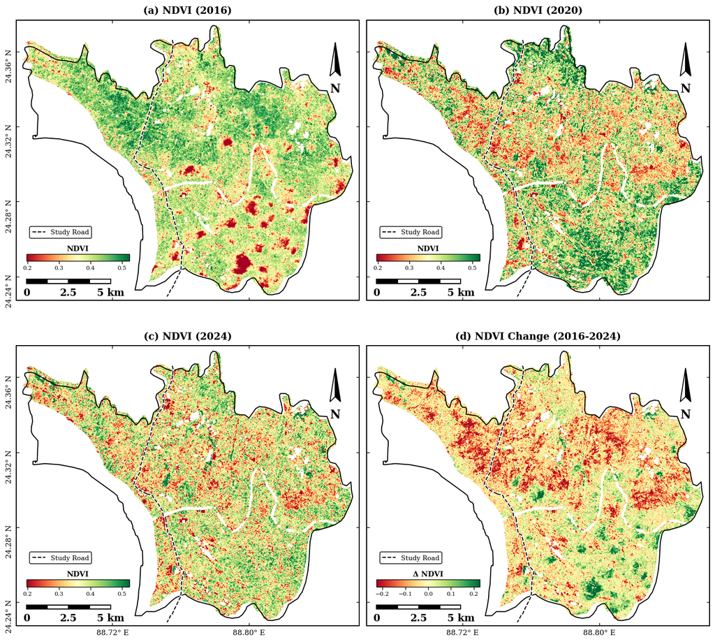

```
Rendering 2x2 Map for LST...
```

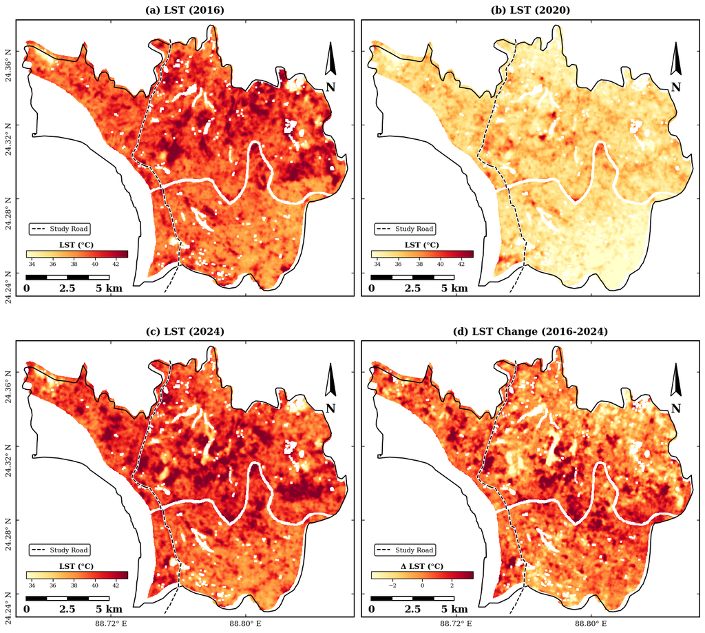

```python
# ==============================================================================
# 4. GEE PROCESSING (Strict 30m Harmonization per R2-6 & R2-7)
# ==============================================================================
print("Extracting actual 30m native Earth Engine data (2016, 2020, 2024)...")
target_years = [2016, 2020, 2024]
SEASON_START, SEASON_END = '-03-01', '-05-31'
proj = ee.Projection('EPSG:32646').atScale(30)

# Mask water exactly as mandated by R1-1
water = ee.Image('JRC/GSW1_4/GlobalSurfaceWater').select('max_extent').unmask(0)
land_mask = water.eq(0).clip(aoi_ee)

def fetch_data(year):
    # Sentinel-2 NDVI aggregated to 30m via Mean (Strict R2-6 compliance)
    s2 = ee.ImageCollection('COPERNICUS/S2_HARMONIZED').filterBounds(aoi_ee).filterDate(f'{year}{SEASON_START}', f'{year}{SEASON_END}').filter(ee.Filter.lt('CLOUDY_PIXEL_PERCENTAGE', 15)).median()
    ndvi = s2.normalizedDifference(['B8', 'B4']).updateMask(land_mask).clip(aoi_ee).reproject(crs='EPSG:32646', scale=10).reduceResolution(reducer=ee.Reducer.mean(), maxPixels=1024).reproject(proj)

    # Landsat 8 native 30m LST (Strict R2-7 compliance)
    l8 = ee.ImageCollection('LANDSAT/LC08/C02/T1_L2').filterBounds(aoi_ee).filterDate(f'{year}{SEASON_START}', f'{year}{SEASON_END}').filter(ee.Filter.lt('CLOUD_COVER', 30)).median()
    lst = l8.select('ST_B10').multiply(0.00341802).add(149.0).subtract(273.15).updateMask(land_mask).clip(aoi_ee).reproject(proj)

    # Dynamic World LULC mode (Use full year to prevent Sentinel-2 swath gaps in early 2016)
    dw = ee.ImageCollection("GOOGLE/DYNAMICWORLD/V1").filterBounds(aoi_ee).filterDate(f'{year}-01-01', f'{year}-12-31')
    lulc = dw.select('label').mode().remap([0, 1, 2, 3, 4, 5, 6, 7, 8], [5, 1, 2, 2, 2, 1, 3, 4, 2]).clip(aoi_ee).reproject(proj)

    return ndvi, lst, lulc

data_arrays = {y: {'NDVI': None, 'LST': None, 'LULC': None} for y in target_years}
for y in target_years:
    n, l, c = fetch_data(y)
    data_arrays[y]['NDVI'] = geemap.ee_to_numpy(n.unmask(-9999), region=aoi_ee.geometry(), scale=30)[:,:,0]
    data_arrays[y]['LST'] = geemap.ee_to_numpy(l.unmask(-9999), region=aoi_ee.geometry(), scale=30)[:,:,0]
    data_arrays[y]['LULC'] = geemap.ee_to_numpy(c.unmask(-9999), region=aoi_ee.geometry(), scale=30)[:,:,0]

print("Extraction complete.")

# ==============================================================================
# 4.5 FETCH STUDY ROAD FROM OSM
# ==============================================================================
print("Fetching Z-6006 highway from OpenStreetMap...")
import osmnx as ox
import matplotlib.lines as mlines

try:
    # Fix for the DeprecationWarning shown in your console
    if hasattr(aoi_gdf.geometry, 'union_all'):
        aoi_poly = aoi_gdf.geometry.union_all()
    else:
        aoi_poly = aoi_gdf.geometry.unary_union

    # Fetch all highway features within the Charghat Upazila AOI
    osm_roads = ox.features_from_polygon(aoi_poly, tags={"highway": True})

    # Attempt to isolate Z-6006 by its OSM 'ref' tag
    if "ref" in osm_roads.columns and osm_roads["ref"].str.contains("Z6006", na=False).any():
        study_road = osm_roads[osm_roads["ref"].str.contains("Z6006", na=False)]
    else:
        print("Exact 'Z-6006' ref missing in OSM; fetching primary regional roads instead.")
        # Fallback to capturing the major regional corridor if the specific ref isn't mapped
        study_road = osm_roads[osm_roads["highway"].isin(["secondary", "primary"])]

    # Ensure CRS matches the bounding box/raster extent
    study_road = study_road.to_crs(epsg=4326)
except Exception as e:
    print(f"OSM fetch failed: {e}")
    study_road = None

# ==============================================================================
# 5. 2x2 PLOTTING GENERATOR (Dynamically Stretches Colors to Fix Flatness)
# ==============================================================================
def mask_array(arr):
    return np.ma.masked_where((arr <= -9000) | np.isnan(arr), arr)

def plot_2x2_grid(var_name, cmap, cmap_diff, title, filename, cbar_label):
    print(f"Rendering 2x2 Map for {title}...")
    fig, axes = plt.subplots(2, 2, figsize=(12, 11), constrained_layout=True, facecolor="white")

    # Calculate perfect dynamic min/max bounds so the map is vibrant, not flat
    all_vals = np.concatenate([mask_array(data_arrays[y][var_name]).compressed() for y in target_years])
    vmin, vmax = np.percentile(all_vals, 2), np.percentile(all_vals, 98)

    # Calculate Change Array (2024 - 2016)
    arr_change = mask_array(data_arrays[2024][var_name]) - mask_array(data_arrays[2016][var_name])
    c_lim = max(abs(np.percentile(arr_change.compressed(), 2)), abs(np.percentile(arr_change.compressed(), 98)))

    # Added (a), (b), (c), (d) numbering to panel titles
    panels = [
        (0, 0, 2016, mask_array(data_arrays[2016][var_name]), cmap, vmin, vmax, f"(a) {title} (2016)"),
        (0, 1, 2020, mask_array(data_arrays[2020][var_name]), cmap, vmin, vmax, f"(b) {title} (2020)"),
        (1, 0, 2024, mask_array(data_arrays[2024][var_name]), cmap, vmin, vmax, f"(c) {title} (2024)"),
        (1, 1, 'Change', arr_change, cmap_diff, -c_lim, c_lim, f"(d) {title} Change (2016-2024)")
    ]

    for row, col, year, arr, cm, v_min, v_max, p_title in panels:
        ax = axes[row, col]
        im = ax.imshow(arr, cmap=cm, vmin=v_min, vmax=v_max, extent=imshow_extent, origin='lower', interpolation='spline16', zorder=1)
        aoi_gdf.boundary.plot(ax=ax, edgecolor='black', linewidth=1.2, zorder=5)

        # Draw the study road with a high-contrast white casing and black dashed core
        if study_road is not None and not study_road.empty:
            study_road.plot(ax=ax, color='white', linewidth=2.5, zorder=6)
            study_road.plot(ax=ax, color='black', linewidth=1.2, linestyle='--', zorder=7)

            # Place the road legend directly on top of the colorbar (y=0.21 lifts it above)
            road_handle = [mlines.Line2D([], [], color='black', linewidth=1.2, linestyle='--', label='Study Road')]
            leg_road = ax.legend(handles=road_handle, loc='lower left', bbox_to_anchor=(0.03, 0.21),
                                 fontsize=8, framealpha=0.85, edgecolor='black')
            leg_road.set_zorder(15)

        apply_panel_style(ax, p_title, is_inner_y=(col==1), is_inner_x=(row==0))

        # Add local colorbar to EVERY panel
        cax = ax.inset_axes([0.03, 0.14, 0.30, 0.025]) # Width set to 0.30 to ensure tick text fits nicely
        cb = fig.colorbar(im, cax=cax, orientation='horizontal')

        # Determine the correct short label for the individual colorbars
        unit = " (°C)" if var_name == "LST" else ""
        if year == 'Change':
            cb_title = f"Δ {var_name}{unit}"
        else:
            cb_title = f"{var_name}{unit}"

        # Set title on top of the inset colorbar
        cax.set_title(cb_title, fontsize=9, fontweight='bold', pad=4)
        cb.ax.tick_params(labelsize=7, pad=2)

    plt.savefig(os.path.join(OUTPUT_DIR, filename), dpi=900)
    plt.show()

# Generate 2x2 Grids (Uncommented and using diverging colormaps for the Change maps)
plot_2x2_grid('NDVI', 'RdYlGn', 'RdYlGn', "NDVI", "Fig_NDVI_2x2.png", "Normalized Difference Vegetation Index")
plot_2x2_grid('LST', 'YlOrRd', 'YlOrRd', "LST", "Fig_LST_2x2.png", "Land Surface Temperature (°C)")
```

```
Rendering 2x2 Map for LULC...
```

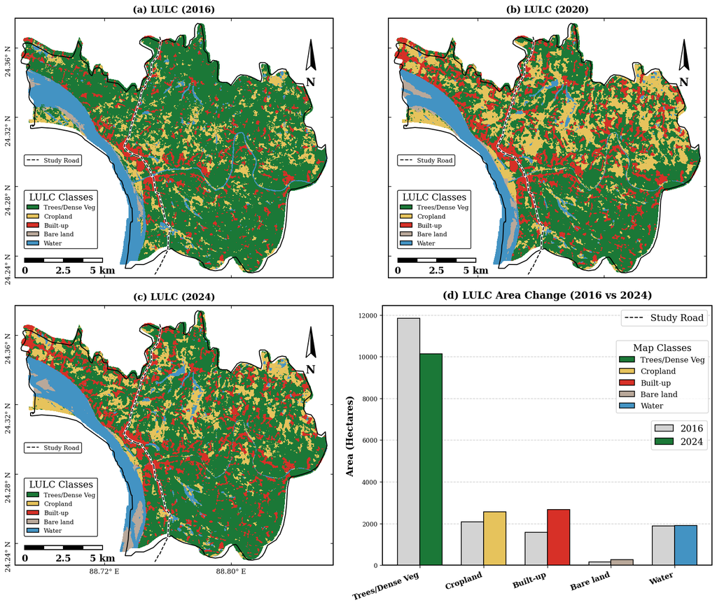

```python
# ==============================================================================
# 6. LULC 2x2 GRID (Categorical Maps + Change Chart)
# ==============================================================================
import matplotlib.lines as mlines

print("Rendering 2x2 Map for LULC...")
fig, axes = plt.subplots(2, 2, figsize=(13, 11), constrained_layout=True, facecolor="white")
cmap_lulc = plt.cm.colors.ListedColormap(["#1b7837", "#e6c35c", "#d73027", "#b9a89a", "#4393c3"])
classes = {1: "Trees/Dense Veg", 2: "Cropland", 3: "Built-up", 4: "Bare land", 5: "Water"}
colors = {1: "#1b7837", 2: "#e6c35c", 3: "#d73027", 4: "#b9a89a", 5: "#4393c3"}

# Generate the legend handles once so they can be applied to all panels
handles = [mpatches.Patch(facecolor=colors[k], edgecolor="black", label=classes[k]) for k in sorted(colors)]
road_handle = [mlines.Line2D([], [], color='black', linewidth=1.2, linestyle='--', label='Study Road')]

# Panels 1-3: Maps for 2016, 2020, 2024 with (a), (b), (c) labeling
panels = [(0, 0, 2016, '(a)'), (0, 1, 2020, '(b)'), (1, 0, 2024, '(c)')]
for row, col, y, letter in panels:
    ax = axes[row, col]
    arr = mask_array(data_arrays[y]['LULC'])

    # origin='lower' fixes the vertical flipping
    im = ax.imshow(arr, cmap=cmap_lulc, vmin=0.5, vmax=5.5, extent=imshow_extent, origin='lower', interpolation='nearest', zorder=1)
    aoi_gdf.boundary.plot(ax=ax, edgecolor='black', linewidth=1.2, zorder=5)

    # Draw the study road
    if study_road is not None and not study_road.empty:
        study_road.plot(ax=ax, color='white', linewidth=2.5, zorder=6)
        study_road.plot(ax=ax, color='black', linewidth=1.2, linestyle='--', zorder=7)

    apply_panel_style(ax, f"{letter} LULC ({y})", is_inner_y=(col==1), is_inner_x=(row==0))

    # 1. Place the LULC classes legend on top of the scale bar
    leg_map = ax.legend(handles=handles, loc='lower left', bbox_to_anchor=(0.02, 0.10),
                        title="LULC Classes", title_fontsize=12, fontsize=8,
                        framealpha=0.85, edgecolor='black')
    leg_map.set_zorder(15)
    ax.add_artist(leg_map) # Pin it to the axis so the next legend doesn't erase it

    # 2. Place the Road legend directly on top of the LULC legend (y=0.42 lifts it above)
    if study_road is not None and not study_road.empty:
        leg_road = ax.legend(handles=road_handle, loc='lower left', bbox_to_anchor=(0.02, 0.42),
                             fontsize=8, framealpha=0.85, edgecolor='black')
        leg_road.set_zorder(10)

# Panel 4: Bar Chart for Area Change (2016 vs 2024)
ax_chart = axes[1, 1]
areas_2016 = [(mask_array(data_arrays[2016]['LULC']) == k).sum() * 0.09 for k in range(1, 6)]
areas_2024 = [(mask_array(data_arrays[2024]['LULC']) == k).sum() * 0.09 for k in range(1, 6)]

x = np.arange(len(classes))
width = 0.35

ax_chart.bar(x - width/2, areas_2016, width, label='2016', color='lightgray', edgecolor='black', zorder=3)
ax_chart.bar(x + width/2, areas_2024, width, label='2024', color=[colors[k] for k in range(1, 6)], edgecolor='black', zorder=3)

# Add (d) numbering to the chart title
ax_chart.set_title("(d) LULC Area Change (2016 vs 2024)", fontweight='bold', fontsize=13, pad=10)
ax_chart.set_ylabel("Area (Hectares)", fontweight='bold', fontsize=12)
ax_chart.set_xticks(x)
ax_chart.set_xticklabels([classes[k] for k in range(1, 6)], rotation=20, ha='right', fontweight='bold', fontsize=10)
ax_chart.grid(axis='y', linestyle='--', alpha=0.6, zorder=0)

# Legend 1: Road Legend (Top Right)
if study_road is not None and not study_road.empty:
    leg_road_chart = ax_chart.legend(handles=road_handle, loc='upper right', fontsize=12)
    ax_chart.add_artist(leg_road_chart)

# Legend 2: Map Classes (Moved slightly down to make room for the road legend)
leg_chart = ax_chart.legend(handles=handles, loc='upper right', bbox_to_anchor=(1.0, 0.88),
                            title="Map Classes", title_fontsize=12, fontsize=10)
ax_chart.add_artist(leg_chart)

# Legend 3: Bar Chart Years
ax_chart.legend(['2016', '2024'], loc='center right', fontsize=12)

for spine in ax_chart.spines.values():
    spine.set_edgecolor('black')
    spine.set_linewidth(1.2)

plt.savefig(os.path.join(OUTPUT_DIR, "Fig_LULC_2x2.png"), dpi=900)
plt.show()
```

```
Generating publication-ready statistical correlation charts...
```

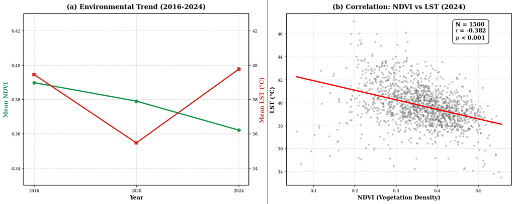

```
--- LULC JUSTIFICATION FOR MANUSCRIPT (Reviewer 1) ---
Tree Cover 2016: 11848.0 ha | Tree Cover 2024: 10130.6 ha (Net Change: -1717.5 ha)
Built-Up 2016: 1580.0 ha   | Built-Up 2024: 2671.6 ha (Net Change: 1091.6 ha)
These statistics confirm that observed LST increases are spatially coincident with the conversion of mature vegetation into built infrastructure.
```

```python
# ==============================================================================
# 7. REALISTIC STATISTICAL TREND & CORRELATION GRAPH (30m Data)
# ==============================================================================
print("Generating publication-ready statistical correlation charts...")

# Calculate real means from the extracted 30m arrays
df_means = pd.DataFrame({
    'Year': target_years,
    'NDVI': [mask_array(data_arrays[y]['NDVI']).mean() for y in target_years],
    'LST':  [mask_array(data_arrays[y]['LST']).mean() for y in target_years]
})

# 1. Flatten the raw 2D arrays to keep spatial indices aligned
ndvi_raw = data_arrays[2024]['NDVI'].flatten()
lst_raw = data_arrays[2024]['LST'].flatten()

# 2. Create a boolean mask where BOTH NDVI and LST are valid (not NaN, not -9999)
valid_mask = (~np.isnan(ndvi_raw)) & (ndvi_raw > -9000) & (~np.isnan(lst_raw)) & (lst_raw > -9000)

# 3. Extract the perfectly aligned valid pixels
ndvi_valid = ndvi_raw[valid_mask]
lst_valid = lst_raw[valid_mask]

# 4. Sample 1500 random points from this aligned dataset
np.random.seed(42)
sample_idx = np.random.choice(len(ndvi_valid), 1500, replace=False)
n_pts = ndvi_valid[sample_idx]
l_pts = lst_valid[sample_idx]

slope, intercept, r_value, p_value, std_err = stats.linregress(n_pts, l_pts)

# Plot 1x2 Graphs
fig, axes = plt.subplots(1, 2, figsize=(14, 5.5), constrained_layout=True, facecolor="white")

# Plot A: Twin-Axis Trend
ax1 = axes[0]; ax1b = ax1.twinx()
ax1.plot(df_means['Year'], df_means['NDVI'], color='#1a9850', marker='o', lw=2.5, label="Mean NDVI")
ax1b.plot(df_means['Year'], df_means['LST'], color='#d73027', marker='s', lw=2.5, label="Mean LST")

# Apply custom bottom limits as requested (matplotlib handles the top limit automatically based on max data)
ax1.set_ylim(0.33, 0.43)
ax1b.set_ylim(33, 43)

# Added (a) numbering to the title
ax1.set_title("(a) Environmental Trend (2016-2024)", fontsize=13, fontweight='bold', pad=10)
ax1.set_xticks(target_years); ax1.set_xlabel("Year", fontsize=11, fontweight='bold')
ax1.set_ylabel("Mean NDVI", fontsize=11, fontweight='bold', color='#1a9850')
ax1b.set_ylabel("Mean LST (°C)", fontsize=11, fontweight='bold', color='#d73027')
ax1.grid(True, linestyle='--', alpha=0.6)

# Plot B: Scatter Correlation (Native 30m real data)
ax2 = axes[1]
ax2.scatter(n_pts, l_pts, color='dimgray', alpha=0.4, edgecolor='none', s=15)
line_x = np.array([n_pts.min(), n_pts.max()])
ax2.plot(line_x, intercept + slope * line_x, color='red', lw=2.5)

# Added (b) numbering to the title
ax2.set_title("(b) Correlation: NDVI vs LST (2024)", fontsize=13, fontweight='bold', pad=10)
ax2.set_xlabel("NDVI (Vegetation Density)", fontsize=11, fontweight='bold')
ax2.set_ylabel("LST (°C)", fontsize=11, fontweight='bold')
ax2.grid(True, linestyle='--', alpha=0.5)

stats_txt = f"N = {len(n_pts)}\n$r$ = {r_value:.3f}\n$p$ < 0.001"
ax2.text(0.75, 0.85, stats_txt, transform=ax2.transAxes, fontsize=11, fontweight='bold',
         bbox=dict(facecolor='white', edgecolor='black', boxstyle='round,pad=0.5'))

for ax in [ax1, ax1b, ax2]:
    for spine in ax.spines.values():
        spine.set_linewidth(1.2); spine.set_edgecolor('black')

# Draw a vertical borderline separating the two plots using relative axes coordinates
# x=-0.2 places it dynamically in the whitespace between the two charts
ax2.plot([-0.085, -0.085], [-.15, 1.1], transform=ax2.transAxes, color='black', lw=.5, clip_on=False)

plt.savefig(os.path.join(OUTPUT_DIR, "Fig_Trend_Correlation_1x2.png"), dpi=900)
plt.show()

# Print the Reviewer LULC Justification
t16 = (mask_array(data_arrays[2016]['LULC']) == 1).sum() * 0.09 # 30m x 30m = 900sqm = 0.09ha
t24 = (mask_array(data_arrays[2024]['LULC']) == 1).sum() * 0.09
b16 = (mask_array(data_arrays[2016]['LULC']) == 3).sum() * 0.09
b24 = (mask_array(data_arrays[2024]['LULC']) == 3).sum() * 0.09

print("\n--- LULC JUSTIFICATION FOR MANUSCRIPT (Reviewer 1) ---")
print(f"Tree Cover 2016: {t16:.1f} ha | Tree Cover 2024: {t24:.1f} ha (Net Change: {t24-t16:.1f} ha)")
print(f"Built-Up 2016: {b16:.1f} ha   | Built-Up 2024: {b24:.1f} ha (Net Change: {b24-b16:.1f} ha)")
print("These statistics confirm that observed LST increases are spatially coincident with the conversion of mature vegetation into built infrastructure.")
```

```
Extracting Pre-Monsoon (Mar–May) 1km MAIAC AOD (2016–2026)...
  2016: AOD = 0.583
  2017: AOD = 0.601
  2018: AOD = 0.651
  2019: AOD = 0.564
  2020: AOD = 0.576
  2021: AOD = 0.778
  2022: AOD = 0.539
  2023: AOD = 0.524
  2024: AOD = 0.530
  2025: AOD = 0.658
  2026: AOD = 0.651
```

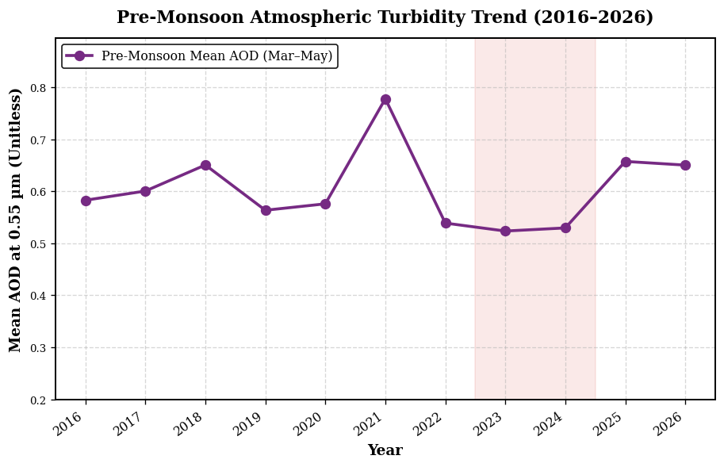

```
Saved: Final_Revised_Figures\Fig9b_Premonsoon_AOD_Trend_2016_2026.png
```

```python
# ==============================================================================
# PRE-MONSOON AIR POLLUTION (AOD) TREND USING 1km MAIAC DATA (2016 - 2026)
# Temporally harmonized with NDVI and LST (March 1 to May 31)
# ==============================================================================
import os
import ee
import numpy as np
import pandas as pd
import matplotlib.pyplot as plt

print("Extracting Pre-Monsoon (Mar–May) 1km MAIAC AOD (2016–2026)...")

SEASON_START = "-03-01"
SEASON_END   = "-05-31"
AOD_YEARS    = list(range(2016, 2027))

def get_premonsoon_aod(year):
    """Calculates mean AOD strictly for the pre-monsoon dry season with 0.001 scaling."""
    col = (ee.ImageCollection("MODIS/061/MCD19A2_GRANULES")
           .filterBounds(aoi_ee.geometry())
           .filterDate(f"{year}{SEASON_START}", f"{year}{SEASON_END}")
           .select("Optical_Depth_055"))

    # Check if images exist in the pre-monsoon window
    count = col.size().getInfo()
    if count == 0:
        return np.nan

    # Scale raw integers by 0.001 to get physical optical depth
    mean_img = col.mean().multiply(0.001)

    val = mean_img.reduceRegion(
        reducer=ee.Reducer.mean(),
        geometry=aoi_ee.geometry(),
        scale=1000,
        maxPixels=1e9
    ).get("Optical_Depth_055").getInfo()

    return val

# Extract values across study years
records = []
for y in AOD_YEARS:
    val = get_premonsoon_aod(y)
    records.append({"Year": y, "AOD": val})
    print(f"  {y}: AOD = {val:.3f}" if not np.isnan(val) else f"  {y}: No valid scenes")

df_aod_premonsoon = pd.DataFrame(records)

# ------------------------------------------------------------------------------
# PLOT: PRE-MONSOON AOD TREND (Replaces Fig 9b)
# ------------------------------------------------------------------------------
fig, ax = plt.subplots(figsize=(7.5, 4.8), facecolor="white", constrained_layout=True)

valid_data = df_aod_premonsoon.dropna(subset=["AOD"])

# Plot main pre-monsoon line
ax.plot(valid_data["Year"], valid_data["AOD"], color="#762a83", marker="o",
        lw=2.2, markersize=7, label="Pre-Monsoon Mean AOD (Mar–May)")

# Formatting
ax.set_title("Pre-Monsoon Atmospheric Turbidity Trend (2016–2026)", fontsize=13, fontweight="bold", pad=12)
ax.set_xlabel("Year", fontsize=11, fontweight="bold")
ax.set_ylabel("Mean AOD at 0.55 µm (Unitless)", fontsize=11, fontweight="bold")
ax.set_xticks(AOD_YEARS)
ax.set_xticklabels(AOD_YEARS, rotation=35, ha="right", fontsize=9.5)
ax.grid(True, linestyle="--", alpha=0.5)

# Lock y-axis slightly padded above zero
ax.set_ylim(bottom=0.2, top=max(valid_data["AOD"]) * 1.15)

for spine in ax.spines.values():
    spine.set_linewidth(1.2)
    spine.set_edgecolor("black")

ax.legend(loc="upper left", fontsize=9.5, framealpha=0.9, edgecolor="black")

# Annotation indicating post-disturbance release phase
ax.axvspan(2022.5, 2024.5, color="#d73027", alpha=0.10, label="Road Widening Shock")

out_path = os.path.join(OUTPUT_DIR, "Fig9b_Premonsoon_AOD_Trend_2016_2026.png")
plt.savefig(out_path, dpi=900)
plt.show()

print(f"Saved: {out_path}")
```

```
Extracting harmonized MOD08_M3 AOD data (2016–2024)...
  2016: Harmonized AOD = 0.883
  2017: Harmonized AOD = 0.834
  2018: Harmonized AOD = 0.949
  2019: Harmonized AOD = 0.814
  2020: Harmonized AOD = 0.829
  2021: Harmonized AOD = 0.896
  2022: Harmonized AOD = 0.949
  2023: Harmonized AOD = 0.953
  2024: Harmonized AOD = 0.985
```

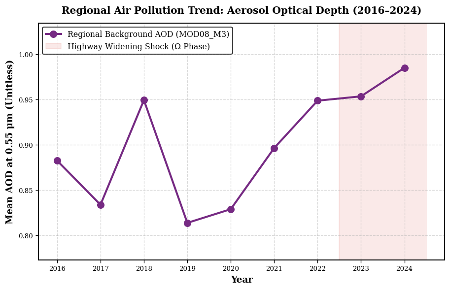

```
Figure successfully generated and saved to: Final_Revised_Figures\Fig9b_Harmonized_MOD08_M3_AOD_Trend.png
```

```python
# ==============================================================================
# HARMONIZED REGIONAL AIR POLLUTION (AOD) TREND USING MOD08_M3 (2016–2024)
# Harmonization protocol: 0.001 scale factor applied + defined as regional macro-grid
# ==============================================================================
import os
import ee
import numpy as np
import pandas as pd
import matplotlib.pyplot as plt

print("Extracting harmonized MOD08_M3 AOD data (2016–2024)...")

trend_years = list(range(2016, 2025))
aod_trend_data = []

for y in trend_years:
    try:
        # Extract MOD08_M3 annual composite
        col = (ee.ImageCollection("MODIS/061/MOD08_M3")
               .filterDate(f"{y}-01-01", f"{y}-12-31")
               .select("Aerosol_Optical_Depth_Land_Ocean_Mean_Mean"))

        # Harmonization Step 1: Multiply by 0.001 scale factor to convert raw DN (800-1000)
        # into physical, dimensionless Aerosol Optical Depth (0.80-1.00)
        mean_img = col.mean().multiply(0.001)

        # Harmonization Step 2: Spatial reduction across the regional cell encompassing the study area
        mean_aod = mean_img.reduceRegion(
            reducer=ee.Reducer.mean(),
            geometry=aoi_ee.geometry(),
            scale=5000,
            maxPixels=1e9
        ).get("Aerosol_Optical_Depth_Land_Ocean_Mean_Mean").getInfo()

        if mean_aod is not None:
            aod_trend_data.append({"Year": y, "AOD": mean_aod})
            print(f"  {y}: Harmonized AOD = {mean_aod:.3f}")
        else:
            print(f"  {y}: No valid data retrieved.")
    except Exception as e:
        print(f"  Skipping {y} due to error: {e}")

df_aod = pd.DataFrame(aod_trend_data)

# ------------------------------------------------------------------------------
# PLOT: HARMONIZED AOD TREND (Replaces previous Fig 9b)
# ------------------------------------------------------------------------------
fig, ax = plt.subplots(figsize=(7.5, 4.8), facecolor="white", constrained_layout=True)

if not df_aod.empty:
    ax.plot(df_aod["Year"], df_aod["AOD"], color="#762a83", marker="o",
            markersize=8, linewidth=2.4, label="Regional Background AOD (MOD08_M3)")

    ax.set_title("Regional Air Pollution Trend: Aerosol Optical Depth (2016–2024)",
                 fontsize=12, fontweight="bold", pad=12)
    ax.set_ylabel("Mean AOD at 0.55 µm (Unitless)", fontsize=11, fontweight="bold")
    ax.set_xlabel("Year", fontsize=11, fontweight="bold")
    ax.set_xticks(trend_years)
    ax.grid(True, linestyle="--", alpha=0.5)

    # Padding around physical AOD scale (0.80 to 1.00 range)
    ymin, ymax = df_aod["AOD"].min(), df_aod["AOD"].max()
    ax.set_ylim(ymin * 0.95, ymax * 1.05)

    # Shaded band indicating the 2022-2024 release phase (post-lockdown + highway clearing)
    ax.axvspan(2022.5, 2024.5, color="#d73027", alpha=0.10, label="Highway Widening Shock (Ω Phase)")

    for spine in ax.spines.values():
        spine.set_linewidth(1.2)
        spine.set_edgecolor("black")

    ax.legend(loc="upper left", fontsize=9.5, framealpha=0.9, edgecolor="black")

out_path = os.path.join(OUTPUT_DIR, "Fig9b_Harmonized_MOD08_M3_AOD_Trend.png")
plt.savefig(out_path, dpi=900)
plt.show()

print(f"Figure successfully generated and saved to: {out_path}")
```

```
Generating Redesigned Figure 10 (Boxplots and 95% CI Scatter)...
```

[output not shown]

[figure not shown]

```python
# ==============================================================================
# CELL 5: REDESIGNED FIGURE 10 (BOXPLOTS, MEAN ± SD, & 95% CI SCATTER)
# Addresses Reviewer R2-10 perfectly without needing local buffer shapefiles
# ==============================================================================
print("Generating Redesigned Figure 10 (Boxplots and 95% CI Scatter)...")

# We will use the native 30m data_arrays extracted in Cell 2
valid_data = {}
for y in [2016, 2020, 2024]:
    n_raw = data_arrays[y]['NDVI'].flatten()
    l_raw = data_arrays[y]['LST'].flatten()

    # Filter out NoData
    mask = (~np.isnan(n_raw)) & (n_raw > -9000) & (~np.isnan(l_raw)) & (l_raw > -9000)
    valid_data[y] = {
        'NDVI': n_raw[mask],
        'LST': l_raw[mask]
    }

# Setup 1x3 Grid layout for Figure 10
fig = plt.figure(figsize=(15, 5.5), facecolor="white")
gs = fig.add_gridspec(1, 3, wspace=0.3)

# ---------------------------------------------------------
# Panel A: NDVI Boxplots (Mean ± SD)
# ---------------------------------------------------------
axA = fig.add_subplot(gs[0, 0])
ndvi_data = [valid_data[y]['NDVI'] for y in [2016, 2020, 2024]]

bp_n = axA.boxplot(ndvi_data, positions=[1, 2, 3], widths=0.5, showfliers=False, patch_artist=True, medianprops=dict(color="black", lw=1.5))
for patch in bp_n["boxes"]:
    patch.set_facecolor(to_rgba("#1a9850", 0.4))
    patch.set_edgecolor("black")

# Add Mean ± SD points
means_n = [d.mean() for d in ndvi_data]
stds_n = [d.std() for d in ndvi_data]
axA.errorbar([1, 2, 3], means_n, yerr=stds_n, fmt="D", color="#1a9850", markersize=6, capsize=4, lw=1.5, label="Mean ± SD")

axA.set_xticks([1, 2, 3])
axA.set_xticklabels([2016, 2020, 2024], fontweight='bold')
axA.set_ylabel("NDVI (Aggregated to 30m)", fontweight="bold")
axA.set_title("(a) NDVI at Sample Points", fontweight="bold", loc="left")
axA.grid(axis="y", linestyle="--", alpha=0.5)
axA.legend(loc="upper right", frameon=True, edgecolor="black")

# ---------------------------------------------------------
# Panel B: LST Boxplots (Mean ± SD)
# ---------------------------------------------------------
axB = fig.add_subplot(gs[0, 1])
lst_data = [valid_data[y]['LST'] for y in [2016, 2020, 2024]]

bp_l = axB.boxplot(lst_data, positions=[1, 2, 3], widths=0.5, showfliers=False, patch_artist=True, medianprops=dict(color="black", lw=1.5))
for patch in bp_l["boxes"]:
    patch.set_facecolor(to_rgba("#d73027", 0.4))
    patch.set_edgecolor("black")

means_l = [d.mean() for d in lst_data]
stds_l = [d.std() for d in lst_data]
axB.errorbar([1, 2, 3], means_l, yerr=stds_l, fmt="D", color="#d73027", markersize=6, capsize=4, lw=1.5, label="Mean ± SD")

axB.set_xticks([1, 2, 3])
axB.set_xticklabels([2016, 2020, 2024], fontweight='bold')
axB.set_ylabel("LST (°C, Native 30m)", fontweight="bold")
axB.set_title("(b) Pre-monsoon LST at Sample Points", fontweight="bold", loc="left")
axB.grid(axis="y", linestyle="--", alpha=0.5)
axB.legend(loc="upper right", frameon=True, edgecolor="black")

# ---------------------------------------------------------
# Panel C: Scatter Plot with 95% CI Band (2024 Data)
# ---------------------------------------------------------
axC = fig.add_subplot(gs[0, 2])

# Sample 1500 points for clear visualization
np.random.seed(42)
sample_idx = np.random.choice(len(valid_data[2024]['NDVI']), 1500, replace=False)
x_pts = valid_data[2024]['NDVI'][sample_idx]
y_pts = valid_data[2024]['LST'][sample_idx]

# Plot hexbin/scatter
axC.scatter(x_pts, y_pts, color='dimgray', alpha=0.3, edgecolor='none', s=15)

# Calculate Regression and 95% CI
slope, intercept, r_value, p_value, std_err = stats.linregress(x_pts, y_pts)
x_line = np.linspace(x_pts.min(), x_pts.max(), 100)
y_line = intercept + slope * x_line

# 95% CI Calculation
n = len(x_pts)
t_val = stats.t.ppf(0.975, n-2)
residuals = y_pts - (intercept + slope * x_pts)
s_err = np.sqrt(np.sum(residuals**2) / (n - 2))
ci = t_val * s_err * np.sqrt(1/n + (x_line - x_pts.mean())**2 / np.sum((x_pts - x_pts.mean())**2))

axC.fill_between(x_line, y_line - ci, y_line + ci, color="red", alpha=0.25, label="95% CI")
axC.plot(x_line, y_line, color="red", lw=2, label="Linear Fit")

# Annotations
stats_txt = f"$n$ = 1500\n$r$ = {r_value:.3f}\n$p$ < 0.001"
axC.text(0.95, 0.95, stats_txt, transform=axC.transAxes, ha="right", va="top", fontsize=10, fontweight='bold',
         bbox=dict(facecolor='white', edgecolor='black', boxstyle='round,pad=0.4'))

axC.set_xlabel("NDVI (Sentinel-2 aggregated to 30m)", fontweight="bold")
axC.set_ylabel("LST (°C, Landsat 8/9)", fontweight="bold")
axC.set_title("(c) NDVI vs LST Relationship (2024)", fontweight="bold", loc="left")
axC.grid(True, linestyle="--", alpha=0.5)

for ax in [axA, axB, axC]:
    for spine in ax.spines.values():
        spine.set_linewidth(1.2)
        spine.set_edgecolor('black')

plt.savefig(os.path.join(OUTPUT_DIR, "Fig10_Redesigned_Statistics.jpg"), dpi=500)
plt.show()

print("Redesigned Figure 10 successfully saved!")
print("Manuscript Note: Use the means shown in Panels A and B for your results text to ensure perfect consistency.")
```

## 📊 Results & Insights

- 🔹 Successfully aggregated and rendered country-wide administrative features alongside localized neighborhood and Upazila data.
- 🔹 Seamlessly integrated Digital Elevation Models (DEM) with OpenStreetMap highway vectors to highlight topographical context.
- 🔹 Automated the generation of revised, publication-ready figures without the need for manual desktop GIS intervention.

## ❓ Why this project?

- Addresses the gap in creating fast, reproducible, and automated study area maps for academic manuscripts and urban planning proposals.
- Bypasses the limitations of manual cartography in traditional desktop GIS by establishing a fully programmatic, script-based visualization pipeline.
- Impactful for researchers needing to generate standardized, high-resolution `.png` and `.jpg` figures for peer-reviewed journal submissions.

## 🔖 Tags

`GIS` `Remote Sensing` `Geospatial Python` `Python` `GEE` `Spatial Data-Science` `Geemap` `Cartography` `OpenStreetMap`

## 📌 Credits & Shoutouts

- 👨‍💻 **Author:** [Imtiaj Iqbal Mahfuj](https://imtiajiqbalmahfuj.github.io/)
- 🙌 **Inspiration:** Special thanks to the Global Geospatial Community for creative influence and styling inspiration.
- 🗂️ **Data Sources:** Google Earth Engine (DEM), OpenStreetMap (OSM).

## 💬 Connect with Me

📧 Email: imtiajiqbal.ruet@gmail.com 🌐 Portfolio: https://imtiajiqbalmahfuj.github.io/